# bank_marketing_ex3

Buthaina Alshareef

01-12-2020

```r
#http://archive.ics.uci.edu/ml/datasets/Bank+Marketing

#read the data set
bank <- read.csv2("data/bank-additional-full.csv", dec = ".")
```

convert all characters to factors

```r
bank[sapply(bank, is.character)] <- lapply(bank[sapply(bank, is.character)],
                                       as.factor)
```

drop duration and nr.employed columns

```r
bank <- select(bank, c (-duration, - nr.employed))
```

```r
dim(bank)
```

```
## [1] 41188    19
```

```r
names(bank)
```

```
##  [1] "age"            "job"            "marital"        "education"
##  [5] "default"        "housing"        "loan"           "contact"
##  [9] "month"          "day_of_week"    "campaign"       "pdays"
## [13] "previous"       "poutcome"       "emp.var.rate"   "cons.price.idx"
## [17] "cons.conf.idx"  "euribor3m"      "y"
```

```r
head(bank)
```

```
##   age       job marital   education default housing loan   contact month
## 1  56 housemaid married    basic.4y      no      no   no telephone   may
## 2  57  services married high.school unknown      no   no telephone   may
## 3  37  services married high.school      no     yes   no telephone   may
## 4  40    admin. married    basic.6y      no      no   no telephone   may
## 5  56  services married high.school      no      no  yes telephone   may
## 6  45  services married    basic.9y unknown      no   no telephone   may
##   day_of_week campaign pdays previous    poutcome emp.var.rate cons.price.idx
## 1         mon        1   999        0 nonexistent          1.1         93.994
## 2         mon        1   999        0 nonexistent          1.1         93.994
## 3         mon        1   999        0 nonexistent          1.1         93.994
## 4         mon        1   999        0 nonexistent          1.1         93.994
## 5         mon        1   999        0 nonexistent          1.1         93.994
## 6         mon        1   999        0 nonexistent          1.1         93.994
##   cons.conf.idx euribor3m  y
## 1         -36.4     4.857 no
## 2         -36.4     4.857 no
## 3         -36.4     4.857 no
## 4         -36.4     4.857 no
## 5         -36.4     4.857 no
## 6         -36.4     4.857 no
```

take the 70% train data set

```r
set.seed(123) # for reproducibility
split <- initial_split(bank, strata = "y", prop = 0.7)
train <- training(split)
test  <- testing(split)
```

#MARS

MARS is not applicable for classification problems, therefore, we are going to use Random Forest

#Random Forest

```r
# number of features
features <- setdiff(names(train), "y")

# perform basic random forest model
fit_default <- ranger(
  formula    = y ~ .,
  data       = train,
  num.trees  = length(features) * 10,
  mtry       = floor(sqrt(length(features))),
  respect.unordered.factors = 'order',
  verbose    = FALSE,
  seed       = 123
  )
```

# Results

Default results are based on OOB errors:

```r
# look at results
fit_default
```

```
## Ranger result
##
## Call:
##  ranger(formula = y ~ ., data = train, num.trees = length(features) *      10, mtry = floor(sqrt(length(features))), respect.unordered.factors = "order",      verbose = FALSE, seed = 123)
##
## Type:                             Classification
## Number of trees:                  180
## Sample size:                      28832
## Number of independent variables:  18
## Mtry:                             4
## Target node size:                 1
## Variable importance mode:         none
## Splitrule:                        gini
## OOB prediction error:             10.14 %
```

```r
# compute RMSE (RMSE = square root of MSE)
fit_default$prediction.error
```

```
## [1] 0.1013804
```

# Characteristics to Consider

What we do next should be driven by attributes of our data:

```r
  train %>%
  summarise_if(is.factor, n_distinct) %>%
  gather() %>%
  arrange(desc(value))
```

```
##            key value
## 1          job    12
## 2        month    10
## 3    education     8
## 4  day_of_week     5
## 5      marital     4
## 6      default     3
## 7      housing     3
## 8         loan     3
## 9     poutcome     3
## 10     contact     2
## 11           y     2
```

Solution: - May favor lower mtry and - lower node size to help decorrelate the trees

OR use PCA OR remove those columns with high correlation

```r
cor_matrix <- train %>%
  mutate_if(is.factor, as.numeric) %>%
  cor()

# feature correlation
data_frame(
  row  = rownames(cor_matrix)[row(cor_matrix)[upper.tri(cor_matrix)]],
  col  = colnames(cor_matrix)[col(cor_matrix)[upper.tri(cor_matrix)]],
  corr = cor_matrix[upper.tri(cor_matrix)]
  ) %>%
  arrange(desc(abs(corr)))
```

```
## # A tibble: 171 x 3
##    row            col              corr
##    <chr>          <chr>           <dbl>
##  1 emp.var.rate   euribor3m       0.972
##  2 emp.var.rate   cons.price.idx  0.775
##  3 cons.price.idx euribor3m       0.686
##  4 contact        cons.price.idx  0.594
##  5 pdays          previous       -0.588
##  6 pdays          poutcome       -0.492
##  7 previous       euribor3m      -0.453
##  8 previous       emp.var.rate   -0.418
##  9 contact        euribor3m       0.403
## 10 contact        emp.var.rate    0.397
## # … with 161 more rows
```

```r
# target correlation
data_frame(
    row  = rownames(cor_matrix)[row(cor_matrix)[upper.tri(cor_matrix)]],
    col  = colnames(cor_matrix)[col(cor_matrix)[upper.tri(cor_matrix)]],
    corr = cor_matrix[upper.tri(cor_matrix)]
) %>% filter(col == "y") %>%
    arrange(desc(abs(corr)))
```

```
## # A tibble: 18 x 3
##    row            col       corr
##    <chr>          <chr>    <dbl>
##  1 pdays          y     -0.328
##  2 euribor3m      y     -0.311
##  3 emp.var.rate   y     -0.300
##  4 previous       y      0.233
##  5 contact        y     -0.147
##  6 cons.price.idx y     -0.134
##  7 poutcome       y      0.134
##  8 default        y     -0.0988
##  9 campaign       y     -0.0639
## 10 education      y      0.0610
## 11 cons.conf.idx  y      0.0538
## 12 marital        y      0.0402
## 13 age            y      0.0365
## 14 job            y      0.0247
## 15 day_of_week    y      0.0134
## 16 housing        y      0.00985
## 17 month          y     -0.00566
## 18 loan           y     -0.00232
```

# Tuning

But before we tune, do we have enough trees

- Some pkgs provide OOB error for each tree
- **ranger** only provides overall OOB
- from this chunk we can know the number of trees with the lowest number of error

```r
# number of features
n_features <- ncol(train) - 1

# ranger function
oob_error <- function(trees) {
  fit <- ranger(
  formula    = y ~ .,
  data       = train,
  num.trees  = trees, #<<
  mtry       = floor(sqrt(n_features)),
  respect.unordered.factors = 'order',
  verbose    = FALSE,
  seed       = 123
  )

  sqrt(fit$prediction.error)
}

# tuning grid
#begin with large
trees <- seq(10, 1000, by = 20)

(error <- trees %>% purrr::map_dbl(oob_error))
```

```
##  [1] 0.3464546 0.3244513 0.3227307 0.3213306 0.3199785 0.3190015 0.3185118
##  [8] 0.3184574 0.3184029 0.3177487 0.3175303 0.3180214 0.3175303 0.3167100
## [15] 0.3166005 0.3173117 0.3170930 0.3169289 0.3173117 0.3170384 0.3171477
## [22] 0.3173117 0.3175849 0.3170384 0.3166552 0.3172571 0.3170930 0.3170384
## [29] 0.3169837 0.3168742 0.3172024 0.3167647 0.3169289 0.3170384 0.3168195
## [36] 0.3166005 0.3167100 0.3165457 0.3168195 0.3166552 0.3166552 0.3168742
## [43] 0.3168195 0.3167647 0.3166005 0.3165457 0.3168742 0.3166005 0.3163265
## [50] 0.3166552
```

arrange the data frame based on the lowest rmse

```r
data.frame(trees, error) %>%
  arrange(error)
```

```
##    trees     error
## 1    970 0.3163265
## 2    750 0.3165457
## 3    910 0.3165457
## 4    290 0.3166005
## 5    710 0.3166005
## 6    890 0.3166005
## 7    950 0.3166005
## 8    490 0.3166552
## 9    790 0.3166552
## 10   810 0.3166552
## 11   990 0.3166552
## 12   270 0.3167100
## 13   730 0.3167100
## 14   630 0.3167647
```

[output cut: 36 more lines]

- the best number of trees is 970 trees with 0.3163265 error
- using $p \times 10 = 180$ trees is sufficient
- may increase if we decrease mtry or sample size

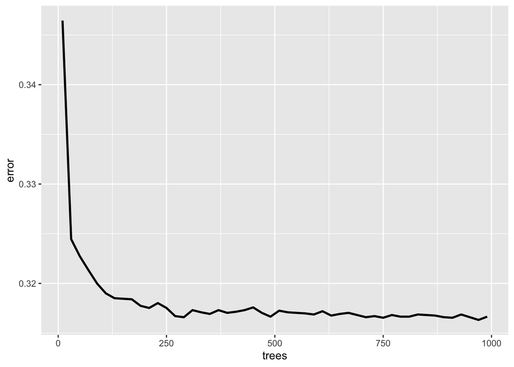

```r
ggplot(data.frame(trees, error), aes(trees, error)) +
  geom_line(size = 1)
```

```r
  # scale_x_continuous(breaks = trees)
```

# Tuning

:Tuning grid

- lower end of mtry range due to correlation
- lower end of node size range due to correlation
- sampling w/o replacement due to categorical features

```r
hyper_grid <- expand.grid(
  mtry            = floor(n_features * c(.05, .15, .25, .333, .4)),
  min.node.size   = c(1, 3, 5),
  replace         = c(TRUE, FALSE),
  sample.fraction = c(.5, .63, .8),
  error            = NA
)

# number of hyperparameter combinations
nrow(hyper_grid)
```

```
## [1] 90
```

```r
head(hyper_grid)
```

```
##   mtry min.node.size replace sample.fraction error
## 1    0             1    TRUE             0.5    NA
## 2    2             1    TRUE             0.5    NA
## 3    4             1    TRUE             0.5    NA
## 4    5             1    TRUE             0.5    NA
## 5    7             1    TRUE             0.5    NA
## 6    0             3    TRUE             0.5    NA
```

Grid search execution

```r
for(i in seq_len(nrow(hyper_grid))) {

  # fit model for ith hyperparameter combination
  fit <- ranger(
    formula         = y ~ .,
    data            = train,
    num.trees       = 970,
    mtry            = hyper_grid$mtry[i],            #<<
    min.node.size   = hyper_grid$min.node.size[i],   #<<
    replace         = hyper_grid$replace[i],         #<<
    sample.fraction = hyper_grid$sample.fraction[i], #<<
    verbose         = FALSE,
    seed            = 123,
    respect.unordered.factors = 'order',
  )

  # export OOB error
  hyper_grid$error[i] <- sqrt(fit$prediction.error)

}
```

# Tuning results

Our top 10 models:

```r
default_error <- sqrt(fit_default$prediction.error)

hyper_grid %>%
  arrange(error) %>%
  mutate(perc_gain = (default_error - error) / default_error * 100) %>%
  head(10)
```

```
##    mtry min.node.size replace sample.fraction     error perc_gain
## 1     2             5    TRUE            0.80 0.3116317  2.126615
## 2     2             3   FALSE            0.50 0.3119654  2.021807
## 3     2             1    TRUE            0.80 0.3122432  1.934552
## 4     2             5   FALSE            0.50 0.3122988  1.917111
## 5     2             3   FALSE            0.63 0.3123543  1.899672
## 6     2             5   FALSE            0.63 0.3124098  1.882237
## 7     2             1   FALSE            0.63 0.3124653  1.864805
## 8     2             1   FALSE            0.50 0.3126318  1.812526
## 9     2             3    TRUE            0.63 0.3126318  1.812526
## 10    2             5    TRUE            0.63 0.3126318  1.812526
```

# Feature Importance

Once you find your optimal model:

- re-run with the respective hyperparameters
- include `importance` parameter
- crank up the # of trees to ensure stable vi estimates

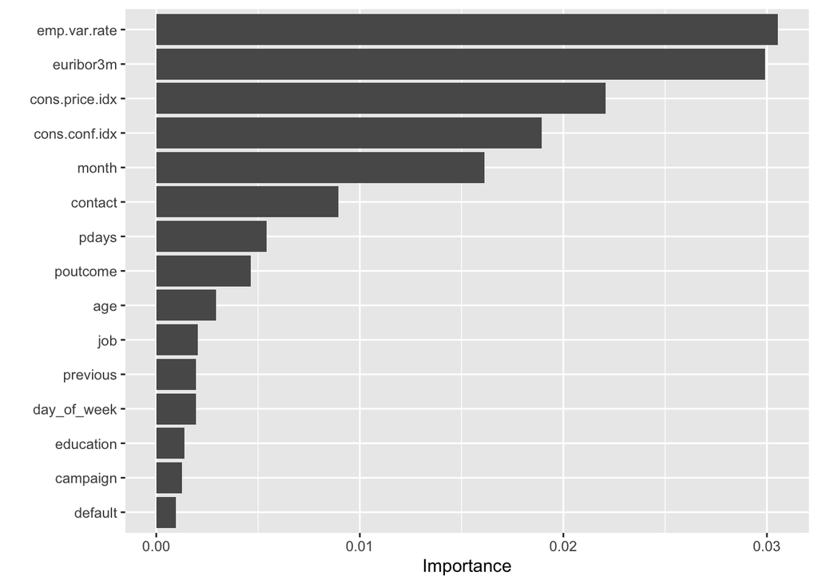

```r
fit_final <- ranger(
  formula         = y ~ .,
  data            = train,
  num.trees       = 970,              #<<
  mtry            = 2,
  min.node.size   = 5,
  sample.fraction = .80,
  replace         = TRUE,
  importance      = 'permutation',     #<<
  respect.unordered.factors = 'order',
  verbose         = FALSE,
  seed            = 123,
  probability = TRUE
  )

vip(fit_final, num_features = 15)
```

# Feature Effects

Partial dependence plots (PDPs), Individual Conditional Expectation (ICE) curves, and other approaches allow us to understand how *important* variables influence our model’s predictions:

PDP: emp.var.rate

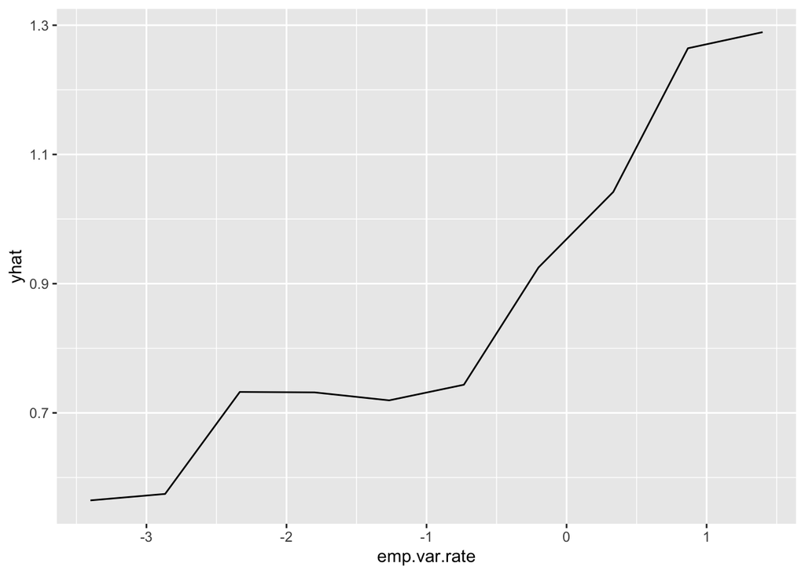

```r
fit_final %>%
  pdp::partial(pred.var = "emp.var.rate", train = as.data.frame(train)) %>%
  autoplot()
```

ICE: emp.var.rate

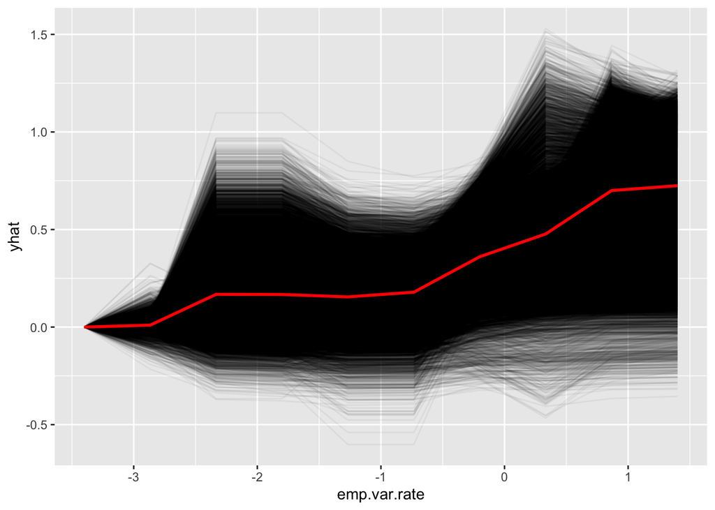

```r
fit_final %>%
  pdp::partial(pred.var = "emp.var.rate", train = as.data.frame(train), ice = TRUE) %>%
  autoplot(alpha = 0.05, center = TRUE)
```

```r
euribor3m_PDP  <- fit_final %>%
  pdp::partial(pred.var = "euribor3m", train = as.data.frame(train)) %>%
  autoplot()
```

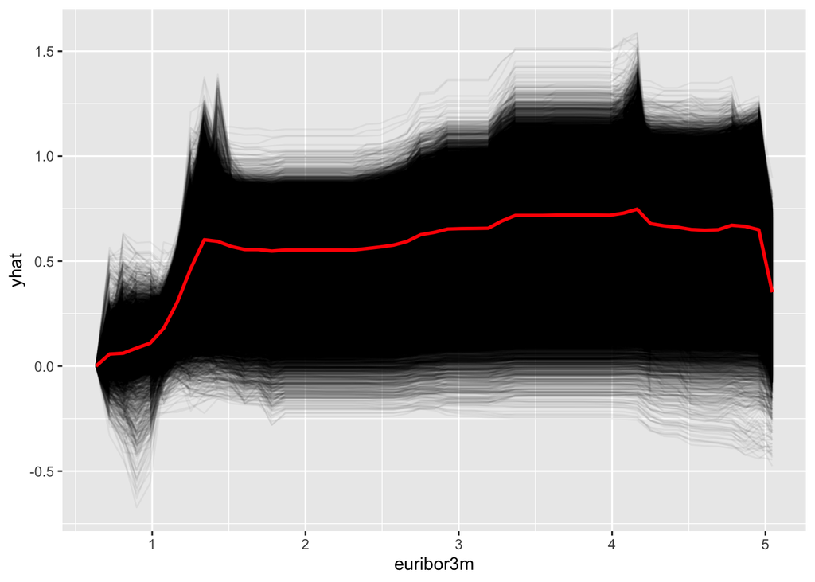

```r
euribor3m_ICE <- fit_final %>%
  pdp::partial(pred.var = "euribor3m", train = as.data.frame(train), ice = TRUE) %>%
  autoplot(alpha = 0.05, center = TRUE)
euribor3m_ICE
```

Interaction between two influential variables:

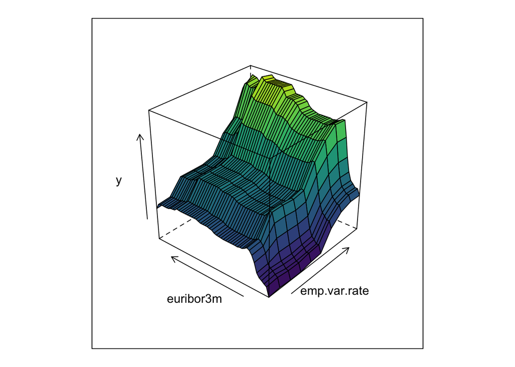

```r
last <- fit_final %>%
  pdp::partial(
    pred.var = c("emp.var.rate", "euribor3m"),
    train = as.data.frame(train)
    ) %>%
  plotPartial(
    zlab = "y",
    levelplot = FALSE,
    drape = TRUE,
    colorkey = FALSE,
    screen = list(z = 50, x = -60)
  )
last
```

```r
#save.image("myWorkspace_ex3.rds")
```

```r
#load("myWorkspace_ex3_1.rds")
```